# Linear Regression in R

Vijay

week 01 session 02

In this session, we will practice implementing basic linear regression in `R` w.r.t. model estimation, model evaluation (in-sample) and model deployment.

## 1. Read in data

Let’s read in the data stored in `UsedCar.csv`.

**Exercise 0:** Read in UsedCar.csv and store it in an R object named `total_data`.

```r
total_data <- read.csv("./UsedCar.csv", header=T, stringsAsFactors=T)
```

We can explore the data briefly.

```r
## We can take a look at the first couple of data entries.
head(total_data, n=2)
```

```
##   Price Age Mileage Fuel_Type HP Metallic Automatic   CC Doors Quarterly_Tax
## 1 13500  23   46986    Diesel 90        1         0 2000     3           210
## 2 13750  23   72937    Diesel 90        1         0 2000     3           210
##   Weight
## 1   1165
## 2   1165
```

```r
## str() gives the structure of the data and date type of each column
str(total_data)
```

```
## 'data.frame':    1436 obs. of  11 variables:
##  $ Price        : int  13500 13750 13950 14950 13750 12950 16900 18600 21500 12950 ...
##  $ Age          : int  23 23 24 26 30 32 27 30 27 23 ...
##  $ Mileage      : int  46986 72937 41711 48000 38500 61000 94612 75889 19700 71138 ...
##  $ Fuel_Type    : Factor w/ 3 levels "CNG","Diesel",..: 2 2 2 2 2 2 2 2 3 2 ...
##  $ HP           : int  90 90 90 90 90 90 90 90 192 69 ...
##  $ Metallic     : int  1 1 1 0 0 0 1 1 0 0 ...
##  $ Automatic    : int  0 0 0 0 0 0 0 0 0 0 ...
##  $ CC           : int  2000 2000 2000 2000 2000 2000 2000 2000 1800 1900 ...
##  $ Doors        : int  3 3 3 3 3 3 3 3 3 3 ...
##  $ Quarterly_Tax: int  210 210 210 210 210 210 210 210 100 185 ...
##  $ Weight       : int  1165 1165 1165 1165 1170 1170 1245 1245 1185 1105 ...
```

```r
## How many observations do we have?
dim(total_data)[1]
```

```
## [1] 1436
```

```r
## How many different variables do we have?
dim(total_data)[2]
```

```
## [1] 11
```

```r
names(total_data)
```

```
##  [1] "Price"         "Age"           "Mileage"       "Fuel_Type"
##  [5] "HP"            "Metallic"      "Automatic"     "CC"
##  [9] "Doors"         "Quarterly_Tax" "Weight"
```

```r
## We can use table() to explore the number of levels for each variable
table(total_data$Fuel_Type)
```

```
##
##    CNG Diesel Petrol
##     17    155   1264
```

**Exercise 1:** How many levels are in the variable `Doors`? Should we treat it as a numerical or categorical variable? How many levels are in the predictor `Automatic` and `Metallic`?

```r
(total_data$Doors)
```

[output not shown]

[output cut: 24 more lines]

## 2. Visualization

We can further do some basic visualization to understand the relationship between the dependent variable and predictors.

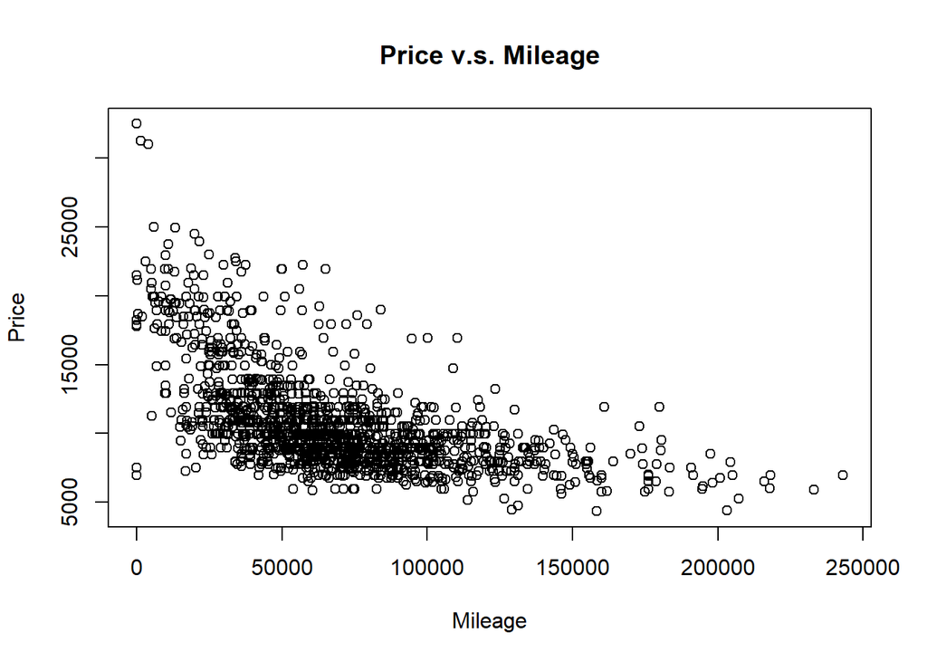

```r
## Scatterplot
plot(total_data$Mileage, total_data$Price, ylab='Price', xlab='Mileage',
     main='Price v.s. Mileage')
```

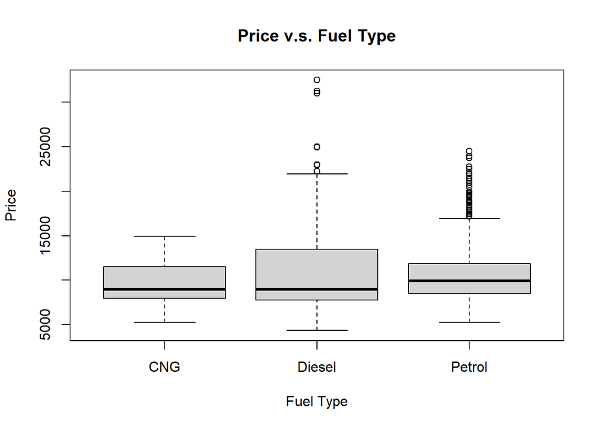

```r
## If the x variable is factor, R will generate side-by-side boxplot
plot(total_data$Fuel_Type, total_data$Price, ylab='Price', xlab='Fuel Type',
     main='Price v.s. Fuel Type')
```

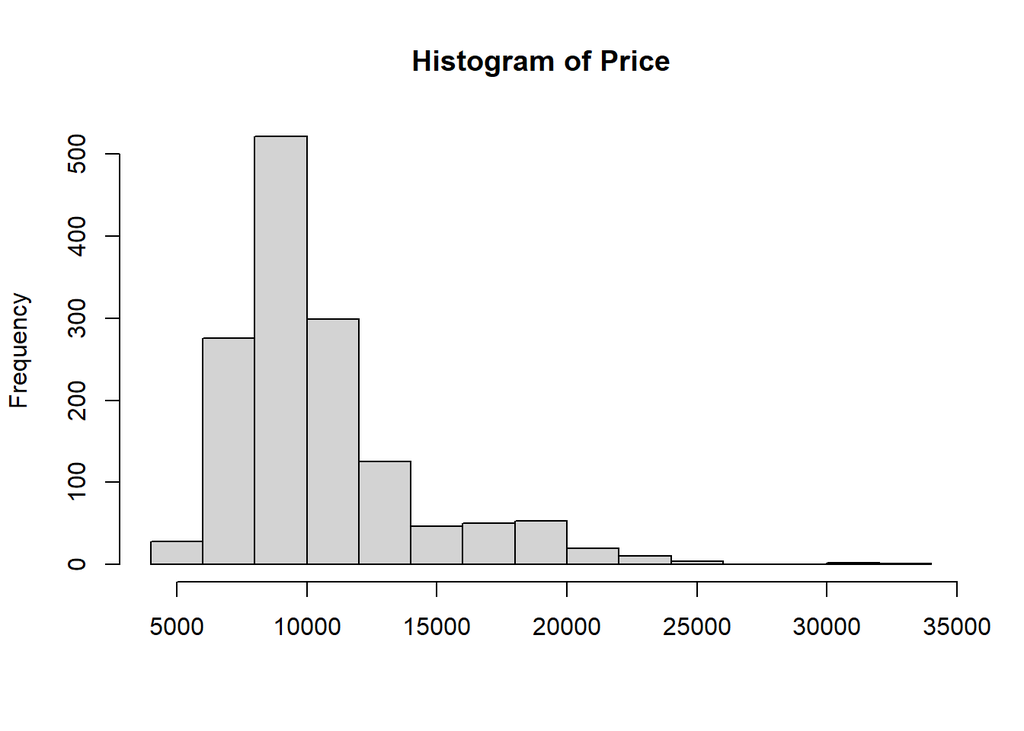

```r
## Histogram of Price
hist(total_data$Price, main='Histogram of Price', xlab='')
```

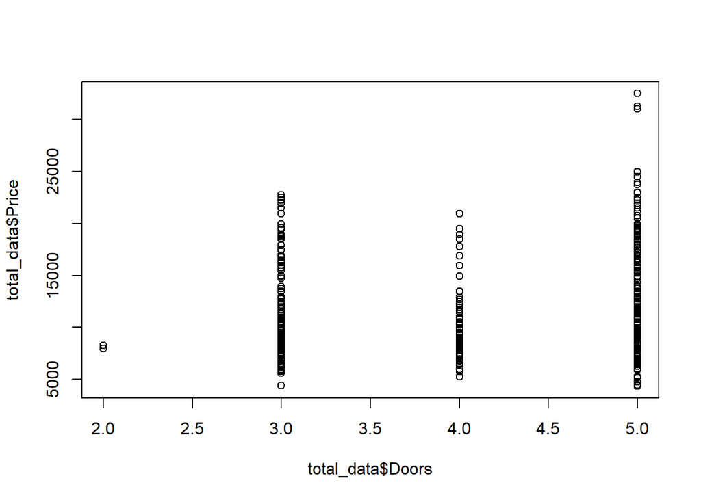

```r
plot(total_data$Doors, total_data$Price)
```

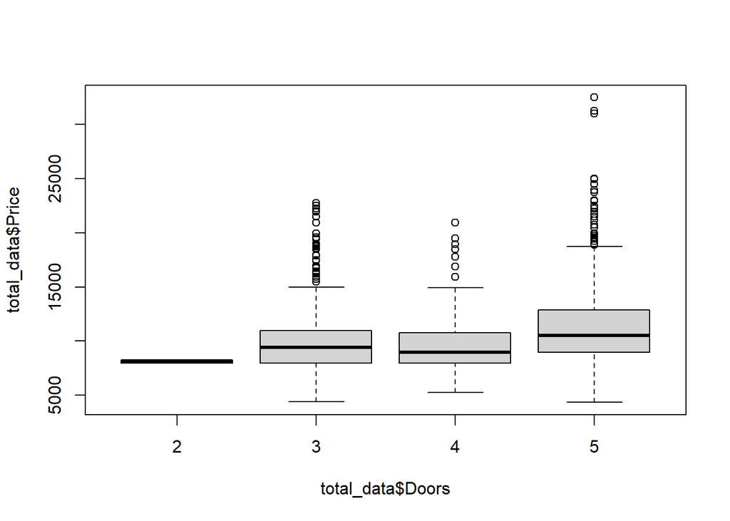

```r
boxplot(total_data$Price~total_data$Doors)
```

The histogram of Price is clearly right-skewed. Let’s do a log-transformation of the original scale Price and store it in a new variable `Log_price`. Let’s further recheck the histogram.

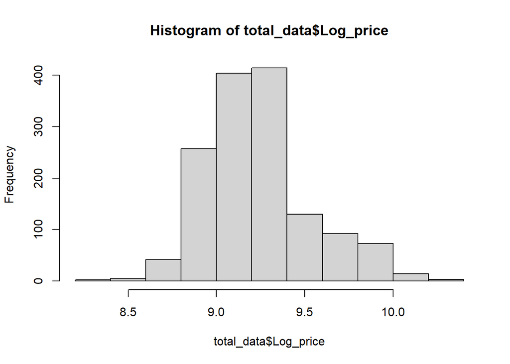

```r
## Log transformation
total_data$Log_price <- log(total_data$Price+1)
total_data$Log_price <- log(total_data$Price+1)
## Histogram of log price
hist(total_data$Log_price)
```

## 3. Linear Regression

### 3.1 Model Estimation

Let’s fit some linear regression models based on the data using the function `lm()`.

```r
## The first model only has an intercept term
lm0 <- lm(Log_price~1, data=total_data)
## The second model is the full model
lm_full <- lm(Log_price~Age+
                Mileage+
                Fuel_Type+
                HP+
                Metallic+
                Automatic+
                CC+
                Doors+
                Quarterly_Tax+
                Weight
              , data=total_data)
## We can also use the following code for convenience. Make sure there is no additional unused variables provided!!!
#lm_full <- lm(Log_price~., data=total_data[,-1])
```

Use the `summary()` function in `R` to look at more details about the fitted linear regression. `lm_full$coefficients` returns the estimated coefficient $\hat{\beta}=(\hat{\beta}_1,\hat{\beta}_2,\cdots,\hat{\beta}_p).$ `lm_full$fitted.values` returns the fitted dependent variable $\hat{Y}=\hat{\beta}_0+\hat{\beta}_1X_1+\cdots+\hat{\beta}_pX_p$ based on estimated coefficient $\hat{\beta}.$

```r
## Look at summary of lm_full

## estimated beta
lm_full$coefficients
```

```
##     (Intercept)             Age         Mileage Fuel_TypeDiesel Fuel_TypePetrol
##    8.485907e+00   -1.047950e-02   -1.677275e-06    5.721951e-02    2.035015e-01
##              HP        Metallic       Automatic              CC           Doors
##    2.066045e-03    3.009097e-03    4.064897e-02   -1.420727e-07    4.472792e-03
##   Quarterly_Tax          Weight
##    1.330551e-03    8.542029e-04
```

**Exercise 3:** Which predictors are statistically significant?

**Exercise 4:** What is the impact of Age to log Price and thus to Price?

### 3.2 Model Evaluation (In-sample Goodness of Fit)

**Exercise 5:** What is $R^2$ of lm_full?

Let’s now manually calculate the $R^2$ of lm_full using the formula discussed in class and verify that it is the same as the one returned by `summary(lm_full)`.

```r
TSS <- sum((total_data$Log_price-mean(total_data$Log_price))^2)
RSS <- sum((total_data$Log_price-lm_full$fitted.values)^2)
## Calculate R^2
```

**Exercise 6:** Is there another way to calculate RSS?

Based on the in-sample residuals, we can calculate popular error measures such as MAE, MAPE, RMSE.

```r
## residuals
error <- lm_full$residuals
MAE <- mean(abs(error))
MAPE <- mean(abs(error/total_data$Log_price))*100
print(c(MAE,MAPE))
```

```
## [1] 0.08467029 0.92239804
```

**Exercise 7:** Calculate RMSE manually.

```r
##
```

We can also use the package `forecast` to generate MAE, MAPE, RMSE automatically

```r
library(forecast)
## first argument is the prediction, second argument is the actual observation
accuracy(lm_full$fitted.values, total_data$Log_price)
```

```
##                    ME      RMSE        MAE         MPE     MAPE
## Test set 2.106901e-17 0.1119404 0.08467029 -0.01492477 0.922398
```

Note that these values may not be very meaningful as the results on in log-scale. We should instead evaluate MAE, MAPE, RMSE at the the original scale. In other words, let’s transform the fitted log Price to Price. How good/accurate is the **in-sample** fit of the linear regression given by lm_full?

```r
## How do we transform the log-scale fitted value to the original scale?
```

### 3.3. Model Deployment

We can use the `predict()` function in `R` to predict log Price at a given predictor value $X$. The `predict()` function is a generic function for generating predictions from a fitted statistical model. It works with the `lm` object created by the `lm()` function.

Let’s read in the new Used Car that we would like to price.

```r
new_cars <- read.csv('./UsedCar_Newdata.csv', header=T, stringsAsFactors=T)
```

Important! Make sure that the new data `new_cars` contains all the predictors used in the fitted linear regression model `lm_full`. There can be extra variables stored in `new_cars`, `predict()` will simply ignore them.

```r
pred_logPrice <- predict(object=lm_full, newdata=new_cars)
pred_Price <- exp(pred_logPrice)-1 # transform back to the original scale
print(pred_Price)
```

```
##         1         2         3         4         5
## 15465.609 20371.642 19435.082  8390.316 11110.854
```

We can also generate prediction intervals for prediction uncertainty quantification at a certain confidence level, say 90%.

```r
pred_logPrice_interval <- predict(object=lm_full, newdata=new_cars, interval='prediction', level=0.9)
## Transform the log-scale prediction back to original scale
# pred_Price_interval <-
# print(pred_Price_interval)
```

Finally, we can combine the prediction results with the new Used Car and export it out as a csv file for reporting. (This step is optional.)

```r
# new_cars <- cbind.data.frame(new_cars, pred_Price_interval)
# write.csv(file='UsedCar_Newdata_Predicted.csv', x=new_cars, row.names=F)
```

## 4. In-class Exercise (Part of HW1)

Fit a linear regression model of Log_price w.r.t. two predictors Age and Mileage, name it `lm_short`.

**Q1** What is the $R^2$ of `lm_short`? Is it higher or lower than the $R^2$ of `lm_full`?

**Q2** What is the estimated coefficient of `lm_short` for Age and Mileage? How should we interpret it at the log-scale and the original scale?

**Q3** Predict the new_cars price at the **original scale** based on `lm_short` and further construct a 90% prediction interval.

```r
# lm_short <-
```